# EDA US Income 1994

Author: Flora Bolonyai

May 2021

```r
# load libraries for analysis
library(haven)
library(tidyverse)
library(survey)
library(magrittr)
library(stargazer)
library(largesamplehl)
options(scipen = 999)
```

## Preprocessing data

Loading the dataset - for the purpose of the exploratory analysis both the original training and test data are used. The total dataset consists of 48842 observations on 15 variables.

```r
# working loc
setwd("/Users/Flora/Documents/Munka/IPEG/test")
vars <- c('age', 'workclass', 'fnlwgt', 'education', 'education_num',
                    'marital_status', 'occupation', 'relationship', 'race', 'sex',
                    'capital_gain', 'capital_loss', 'hours_per_week', 'native_country',
                    'label')
data <- read.csv("archive/adult.data", strip.white = T, stringsAsFactors = T, header = F)
colnames(data) <- vars
data_test <- read.csv("archive/adult.test", strip.white = T, stringsAsFactors = T, skip = 1, header = F)
colnames(data_test) <- vars
data <- rbind(data, data_test)
```

## Quality assessment

First glances at the data:

```r
# structure of the data
str(data)
```

```
## 'data.frame':    48842 obs. of  15 variables:
##  $ age           : int  39 50 38 53 28 37 49 52 31 42 ...
##  $ workclass     : Factor w/ 9 levels "?","Federal-gov",..: 8 7 5 5 5 5 5 7 5 5 ...
##  $ fnlwgt        : int  77516 83311 215646 234721 338409 284582 160187 209642 45781 159449 ...
##  $ education     : Factor w/ 16 levels "10th","11th",..: 10 10 12 2 10 13 7 12 13 10 ...
##  $ education_num : int  13 13 9 7 13 14 5 9 14 13 ...
##  $ marital_status: Factor w/ 7 levels "Divorced","Married-AF-spouse",..: 5 3 1 3 3 3 4 3 5 3 ...
##  $ occupation    : Factor w/ 15 levels "?","Adm-clerical",..: 2 5 7 7 11 5 9 5 11 5 ...
##  $ relationship  : Factor w/ 6 levels "Husband","Not-in-family",..: 2 1 2 1 6 6 2 1 2 1 ...
##  $ race          : Factor w/ 5 levels "Amer-Indian-Eskimo",..: 5 5 5 3 3 5 3 5 5 5 ...
##  $ sex           : Factor w/ 2 levels "Female","Male": 2 2 2 2 1 1 1 2 1 2 ...
##  $ capital_gain  : int  2174 0 0 0 0 0 0 0 14084 5178 ...
##  $ capital_loss  : int  0 0 0 0 0 0 0 0 0 0 ...
##  $ hours_per_week: int  40 13 40 40 40 40 16 45 50 40 ...
##  $ native_country: Factor w/ 42 levels "?","Cambodia",..: 40 40 40 40 6 40 24 40 40 40 ...
##  $ label         : Factor w/ 4 levels "<=50K",">50K",..: 1 1 1 1 1 1 1 2 2 2 ...
```

```r
# summary statistics of the data
summary(data)
```

```
##       age                   workclass         fnlwgt
##  Min.   :17.00   Private         :33906   Min.   :  12285
##  1st Qu.:28.00   Self-emp-not-inc: 3862   1st Qu.: 117550
##  Median :37.00   Local-gov       : 3136   Median : 178144
##  Mean   :38.64   ?               : 2799   Mean   : 189664
##  3rd Qu.:48.00   State-gov       : 1981   3rd Qu.: 237642
##  Max.   :90.00   Self-emp-inc    : 1695   Max.   :1490400
##                  (Other)         : 1463
##         education     education_num                 marital_status
##  HS-grad     :15784   Min.   : 1.00   Divorced             : 6633
##  Some-college:10878   1st Qu.: 9.00   Married-AF-spouse    :   37
##  Bachelors   : 8025   Median :10.00   Married-civ-spouse   :22379
##  Masters     : 2657   Mean   :10.08   Married-spouse-absent:  628
##  Assoc-voc   : 2061   3rd Qu.:12.00   Never-married        :16117
##  11th        : 1812   Max.   :16.00   Separated            : 1530
##  (Other)     : 7625                   Widowed              : 1518
##            occupation            relationship                   race
##  Prof-specialty : 6172   Husband       :19716   Amer-Indian-Eskimo:  470
##  Craft-repair   : 6112   Not-in-family :12583   Asian-Pac-Islander: 1519
##  Exec-managerial: 6086   Other-relative: 1506   Black             : 4685
##  Adm-clerical   : 5611   Own-child     : 7581   Other             :  406
##  Sales          : 5504   Unmarried     : 5125   White             :41762
##  Other-service  : 4923   Wife          : 2331
##  (Other)        :14434
##      sex         capital_gain    capital_loss    hours_per_week
##  Female:16192   Min.   :    0   Min.   :   0.0   Min.   : 1.00
##  Male  :32650   1st Qu.:    0   1st Qu.:   0.0   1st Qu.:40.00
##                 Median :    0   Median :   0.0   Median :40.00
##                 Mean   : 1079   Mean   :  87.5   Mean   :40.42
##                 3rd Qu.:    0   3rd Qu.:   0.0   3rd Qu.:45.00
##                 Max.   :99999   Max.   :4356.0   Max.   :99.00
##
##        native_country     label
##  United-States:43832   <=50K :24720
##  Mexico       :  951   >50K  : 7841
##  ?            :  857   <=50K.:12435
##  Philippines  :  295   >50K. : 3846
##  Germany      :  206
##  Puerto-Rico  :  184
##  (Other)      : 2517
```

Looks like the dataset contains mostly what is expected based on the descripton of the data. There is some problem with the ‘label’ variable as it has 4 levels, the fnlwgt variable seems to be left unscaled, while there could be some potential outliers in the ‘capital_gain’ and ‘hours_per_week’ variables. Additionally, some of the variables take on ‘?’ as a value, which is used to signal missing/unavailable data.

```r
# fixing 'label'
data[data$label=='<=50K.',]$label <- '<=50K'
data[data$label=='>50K.',]$label <- '>50K'
data$label <- factor(data$label)

# fixed label
summary(data$label)
```

```
## <=50K  >50K
## 37155 11687
```

```r
# scaling the fnlwgt variable to have mean = 1 and sum = N
data$anwgt <- data$fnlwgt/mean(data$fnlwgt)
```

In the next few steps, I continue the assessment of the quality of the dataset. First, I have a better look at ‘?’ values, then I check for outliers and duplicate rows, and finally I look for inconsistencies among the variables.

1. Looking at missing/unknown values

```r
# replace '?' by na for easier handling
data %<>% mutate(across(.fns = ~replace(., . ==  '?' , NA)))

# check for missing data -- NA
data %>%
    select_if(function(x) any(is.na(x))) %>%
    summarize(across(.fns = ~sum(is.na(.x)))) -> extra_NA

extra_NA
```

```
##   workclass occupation native_country
## 1      2799       2809            857
```

```r
data_na <- anti_join(data, na.omit(data))
nrow(data_na)
```

```
## [1] 3620
```

```r
nrow(data_na[is.na(data_na$workclass)&is.na(data_na$occupation),])
```

```
## [1] 2799
```

There are a total of 6465 unknown values in the dataset, corresponding for a total of 3620 rows, which means that approximately 7.5% of the observations have missing values. In the case of 2799 observations, both the ‘workclass’ and ‘occupation’ variables are unavailable. Considering the nature of the variables with the missing values, and without any information about previous employment of the individuals, it would be rather difficult to impute the missing data. Similarly, using the available data, it would be difficult to determine the native country of those individuals for whom this information is unknown.

2. Checking for outliers

To check for outliers, let’s look at the distribution of those variables that potentially contain problematic values, ‘capital_gain’ and ‘hours_per_week’.

- Capital gain

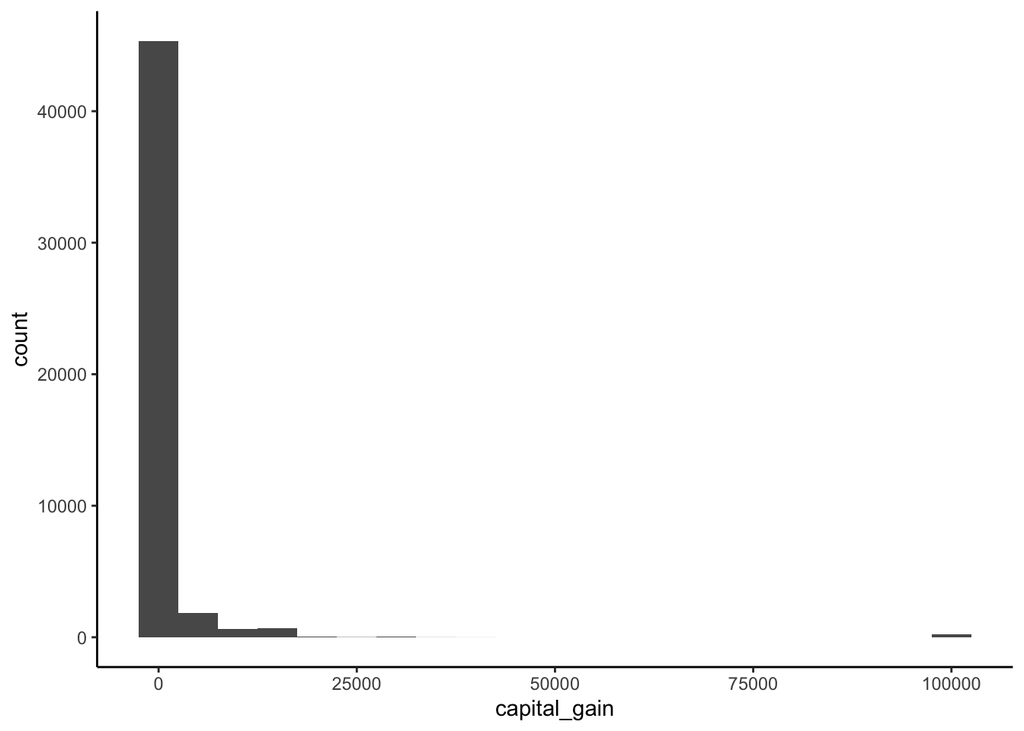

```r
ggplot(data = data) +
    aes(x=capital_gain, weight = anwgt) +
    geom_histogram(binwidth =5000) +
    theme_classic()
```

```r
nrow(data[data$capital_gain > 45000,])
```

```
## [1] 244
```

```r
nrow(data[data$capital_gain==99999,])
```

```
## [1] 244
```

```r
weighted.mean(data$capital_gain, data$anwgt)
```

```
## [1] 1063.689
```

```r
weighted.mean(data[data$capital_gain<99999,]$capital_gain, data[data$capital_gain<99999,]$anwgt)
```

```
## [1] 577.7898
```

It is clear that there are some people with extraordinary high capital gains compared to the rest of the individuals. Moreover, they all have the same value as their capital gain, so it is likely that something is not completely true about these values. However, it is unclear whether they are completely false, or perhaps all larger numbers are just set to the highest possible 5-digit value. Overall, these values are likely to create significant bias: the average capital gain including the observations with extreme capital gaain is approximately USD 1064, while it is only USD 578 if the extreme values are removed.

- Weekly hours worked

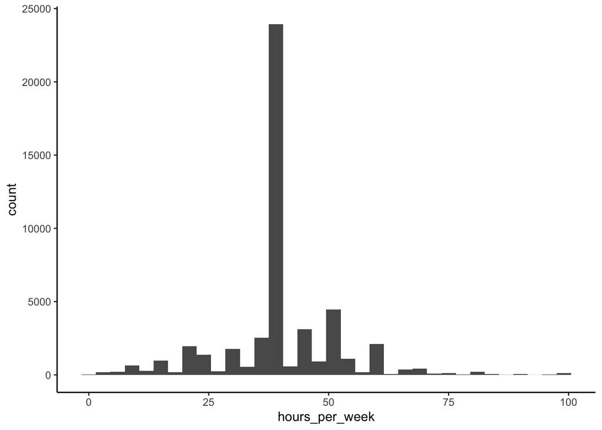

```r
ggplot(data = data) +
    aes(x=hours_per_week, weight = anwgt) +
    geom_histogram(binwidth =3) +
    theme_classic()
```

```r
nrow(data[data$hours_per_week > 60,])
```

```
## [1] 1676
```

```r
nrow(data[data$hours_per_week == 99,])
```

```
## [1] 137
```

While the distribution of weekly worked hours also shows some extreme values, it is less likely that these values are false data. In the case of capital gains we could observe a large break between the general larger values of the variable and its maximum, but this is not the case with weekly hours, as several observations fall between the reasonably high number of ours and the maximum of the variable.

3. Checking duplicates

```r
nrow(data[duplicated(data),])
```

```
## [1] 52
```

```r
#data[duplicated(data),]
```

The dataset contains 52 duplicated rows. This is a very small proportion of the total amount of available data which can easily be caused by randomness considering how some variables have truly dominant values. Keeping or removing these duplicate rows is not likely to influence the results of data analysis.

4. Checking for inconsistencies As the dataset comes from a survey, it is possible to find some deterministic relationship between variables. E.g. in the case of this survey, we can check the cross tabulations of sex and relationship, marital status and relationship, the categorical and numerical versions of the education variable, as well as age and education.

```r
# gender x relationship
table(data$sex, data$relationship)
```

```
##
##          Husband Not-in-family Other-relative Own-child Unmarried  Wife
##   Female       1          5870            689      3376      3928  2328
##   Male     19715          6713            817      4205      1197     3
```

```r
#data[data$sex == 'Female' & data$relationship == 'Husband',]
#data[data$sex == 'Male' & data$relationship == 'Wife',]

# marital status x relationship
table(data$marital_status, data$relationship)
```

```
##
##                         Husband Not-in-family Other-relative Own-child
##   Divorced                    0          3628            181       455
##   Married-AF-spouse          12             0              1         1
##   Married-civ-spouse      19704            23            201       143
##   Married-spouse-absent       0           330             54        61
##   Never-married               0          7114            920      6750
##   Separated                   0           637             79       146
##   Widowed                     0           851             70        25
##
##                         Unmarried  Wife
##   Divorced                   2369     0
##   Married-AF-spouse             0    23
##   Married-civ-spouse            0  2308
##   Married-spouse-absent       183     0
##   Never-married              1333     0
##   Separated                   668     0
##   Widowed                     572     0
```

```r
# education x education in years
table(data$education, data$education_num)
```

```
##
##                    1     2     3     4     5     6     7     8     9    10
##   10th             0     0     0     0     0  1389     0     0     0     0
##   11th             0     0     0     0     0     0  1812     0     0     0
##   12th             0     0     0     0     0     0     0   657     0     0
##   1st-4th          0   247     0     0     0     0     0     0     0     0
##   5th-6th          0     0   509     0     0     0     0     0     0     0
##   7th-8th          0     0     0   955     0     0     0     0     0     0
##   9th              0     0     0     0   756     0     0     0     0     0
##   Assoc-acdm       0     0     0     0     0     0     0     0     0     0
##   Assoc-voc        0     0     0     0     0     0     0     0     0     0
##   Bachelors        0     0     0     0     0     0     0     0     0     0
##   Doctorate        0     0     0     0     0     0     0     0     0     0
##   HS-grad          0     0     0     0     0     0     0     0 15784     0
##   Masters          0     0     0     0     0     0     0     0     0     0
##   Preschool       83     0     0     0     0     0     0     0     0     0
##   Prof-school      0     0     0     0     0     0     0     0     0     0
##   Some-college     0     0     0     0     0     0     0     0     0 10878
##
##                   11    12    13    14    15    16
##   10th             0     0     0     0     0     0
##   11th             0     0     0     0     0     0
##   12th             0     0     0     0     0     0
##   1st-4th          0     0     0     0     0     0
##   5th-6th          0     0     0     0     0     0
##   7th-8th          0     0     0     0     0     0
##   9th              0     0     0     0     0     0
##   Assoc-acdm       0  1601     0     0     0     0
##   Assoc-voc     2061     0     0     0     0     0
##   Bachelors        0     0  8025     0     0     0
##   Doctorate        0     0     0     0     0   594
##   HS-grad          0     0     0     0     0     0
##   Masters          0     0     0  2657     0     0
##   Preschool        0     0     0     0     0     0
##   Prof-school      0     0     0     0   834     0
##   Some-college     0     0     0     0     0     0
```

```r
# age x education
data[data$age<20 & data$education_num>12,]
```

```
##       age workclass fnlwgt education education_num marital_status
## 1571   19      <NA>  62534 Bachelors            13  Never-married
## 3592   19   Private 100999 Bachelors            13  Never-married
## 12184  18 Local-gov 155905   Masters            14  Never-married
##           occupation relationship  race    sex capital_gain capital_loss
## 1571            <NA>    Own-child Black Female            0            0
## 3592  Prof-specialty    Own-child White Female            0            0
## 12184 Prof-specialty    Own-child White Female            0            0
##       hours_per_week native_country label     anwgt
## 1571              40        Jamaica <=50K 0.3297091
## 3592              30  United-States <=50K 0.5325150
## 12184             60  United-States <=50K 0.8220057
```

From the possible inconsistencies, we can detect 4 rows where the gender and relationship in the household seem to be conflicting (considering the data is from 1994), while we can also see three cases where considering the age of the respondent, their highest level of education seems questionable.

#### Final quality check - visualizations

The easiest way to handle the missing/problematic values is to leave them out of the dataset. To see how this would effect the data overall, let’s look at how the main demographic distributions change if the most problematic rows are removed. As I won’t be using the capital gain and capital loss variables during my further explorations, removing the rows taking on extreme values in this variable is not part of the cleaning process.

```r
# check if demo distribution data w/o rows with missing values and inconsistencies
# is similar to original -- race, age, gender
data_cl <- distinct(data)
data_cl <- data_cl %>% drop_na()
data_cl <- data_cl[!(data_cl$sex == 'Female' & data_cl$relationship == 'Husband'),]
data_cl <- data_cl[!(data_cl$sex == 'Male' & data_cl$relationship == 'Wife'),]
data_cl <- data_cl[!(data_cl$age<20 & data_cl$education_num>12),]
data_cl$workclass <- factor(data_cl$workclass)
data_cl$occupation <- factor(data_cl$occupation)
data_cl$native_country <- factor(data_cl$native_country)
data$total <- 'original'
data_cl$total <- 'cleaned'
plot_data <- rbind(data, data_cl)
```

AGE

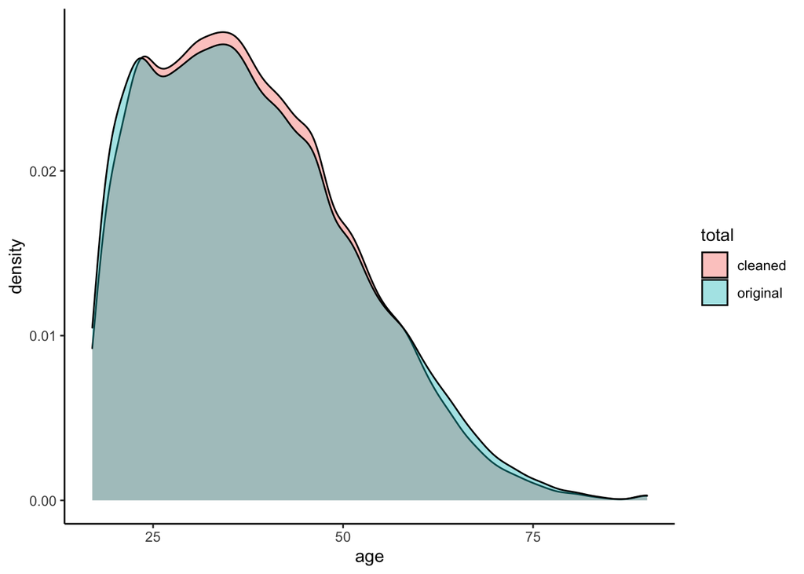

```r
ggplot(plot_data, aes(x=age, fill = total, weight = anwgt)) +
    geom_density(alpha = .4) +
    theme_classic()
```

GENDER

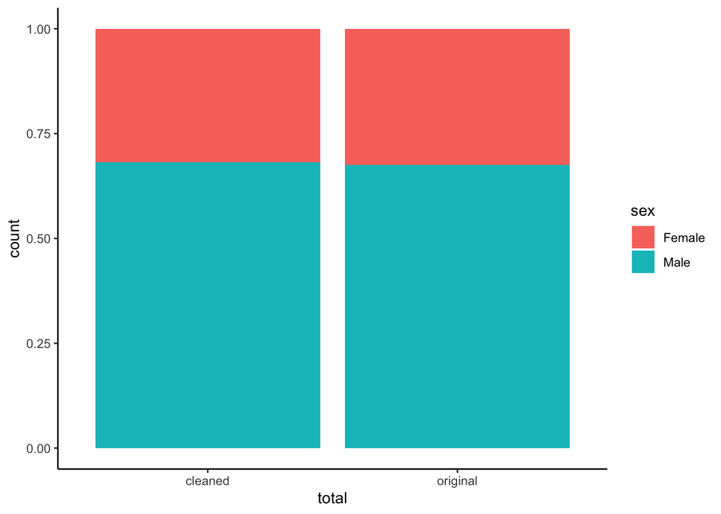

```r
ggplot(plot_data, aes(x=total, fill=sex, weight = anwgt)) +
    geom_bar(position="fill", stat="count") +
    theme_classic()
```

RACE

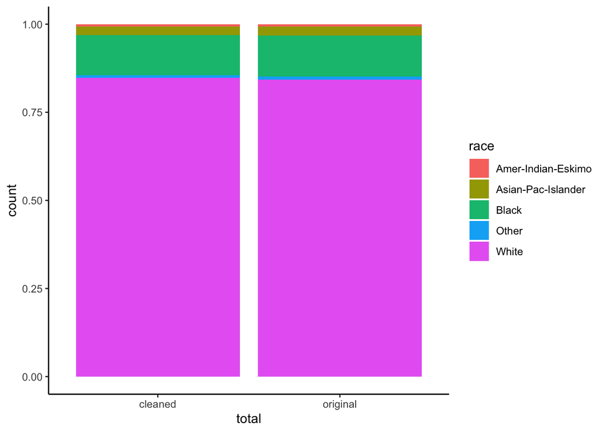

```r
ggplot(plot_data, aes(x=total, fill=race, weight = anwgt)) +
    geom_bar(position="fill", stat="count") +
    theme_classic()
```

Overall there is little visible difference in the distributions of the ‘cleaned’ and original version of the dataset. The quality of the data is rather good, and the sample size allows for the deletion of 7.5% of the data without causing significant changes in the distribution of the variables according to which the dataset represents the demographic compositions of the US states.

## Extracting insights - descriptive statistics

#### Bivariate explorations

```r
wtd_dt<-svydesign(id=~1, weights=~anwgt, data=data_cl)
svytable(~label, wtd_dt)
```

```
## label
##    <=50K     >50K
## 34062.62 11126.03
```

```r
round(svymean(~label, wtd_dt),2)
```

```
##            mean     SE
## label<=50K 0.75 0.0023
## label>50K  0.25 0.0023
```

Although the ultimate goal of this exploratory data analysis is not a predictive model, I still chose to explore how the different demographic and labor variables relate to having a higher annual income than $50K. One variable I’m specifically interest in is gender, so I’m trying to explore how someone’s gender influenced the probability of having an income above USD 50K in 1994. Overall, nearly 25% of the sample belongs to the >50K group.

To have an understanding of the variables that are potentially related to having an annual income of above USD 50K, let’s look at how the proportion of individuals having an income above USD 50K is different across the different levels of the demographic and labor variables.

gender x earnings

```r
wtd_dt<-svydesign(id=~1, weights=~anwgt, data=data_cl)
round(svytable(~sex + label, wtd_dt),0)
```

```
##         label
## sex      <=50K  >50K
##   Female 12739  1622
##   Male   21324  9504
```

```r
round(prop.table(svytable(~sex + label, wtd_dt), margin = 1),2)
```

```
##         label
## sex      <=50K >50K
##   Female  0.89 0.11
##   Male    0.69 0.31
```

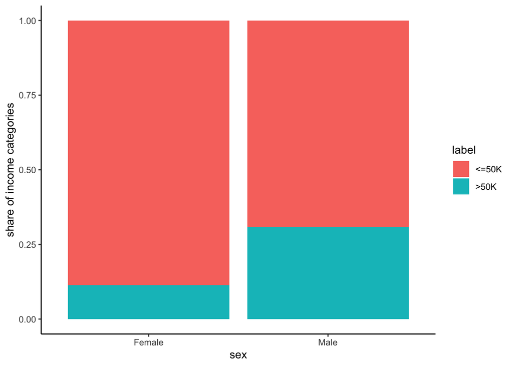

```r
ggplot(data_cl, aes(x=sex, fill=label, weight = anwgt)) +
    geom_bar(position="fill", stat="count") +
    ylab("share of income categories") +
    theme_classic()
```

The crosstabs show that the majority of the sample is made of men, which aligns with general assumptions about the US labor force in 1994. As of the proportion of women and men making more than USD 50K, it’s clear that men were in a better position: while barely 11% of women in the sample fall in this category, nearly 31% of men in the sample made more than USD 50K.

age x earnings

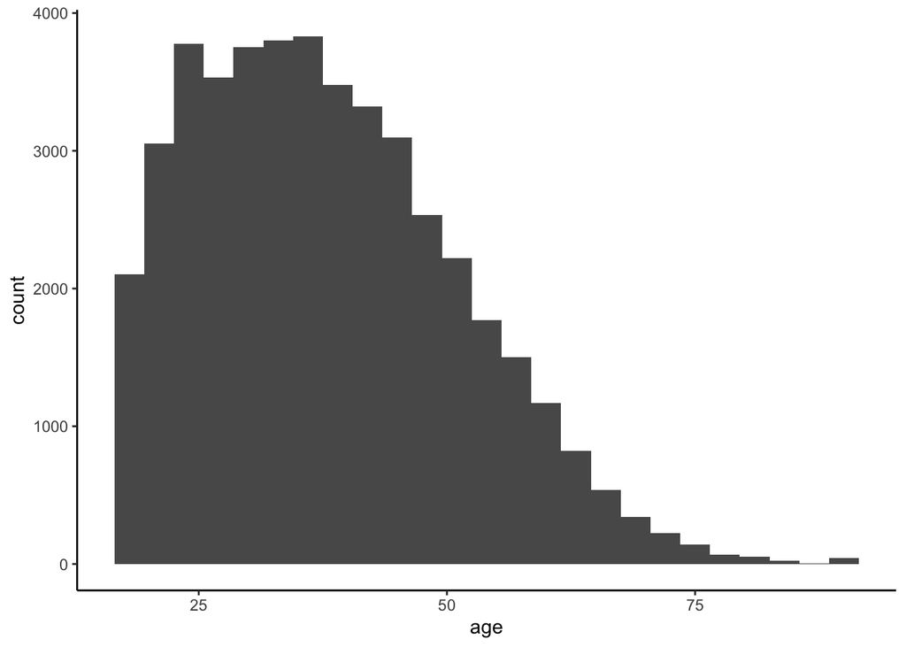

```r
ggplot(data = data_cl) +
    aes(x=age, weight = anwgt) +
    geom_histogram(binwidth =3) +
    theme_classic()
```

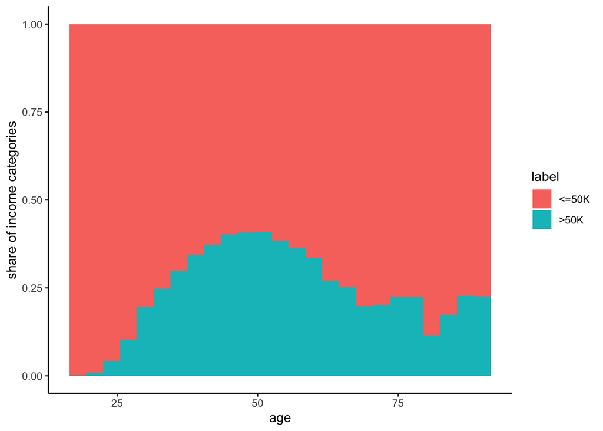

```r
ggplot(data = data_cl) +
    aes(x=age, fill=label, weight = anwgt) +
    geom_histogram(binwidth =3, position='fill') +
    ylab("share of income categories") +
    theme_classic()
```

Age and the likelihood of making above USD 50K are also related as expected: until around 50, being older means higher probability to belong in the >50K group, while starting from the age of 50, the probability decreases. Elderly people show a slightly different pattern, however, their absolute number in the sample is marginal.

race x earnings

```r
round(svytable(~race + label, wtd_dt),0)
```

```
##                     label
## race                 <=50K  >50K
##   Amer-Indian-Eskimo   247    35
##   Asian-Pac-Islander   772   316
##   Black               4491   667
##   Other                315    46
##   White              28238 10062
```

```r
round(prop.table(svytable(~race + label, wtd_dt), margin = 1),2)
```

```
##                     label
## race                 <=50K >50K
##   Amer-Indian-Eskimo  0.88 0.12
##   Asian-Pac-Islander  0.71 0.29
##   Black               0.87 0.13
##   Other               0.87 0.13
##   White               0.74 0.26
```

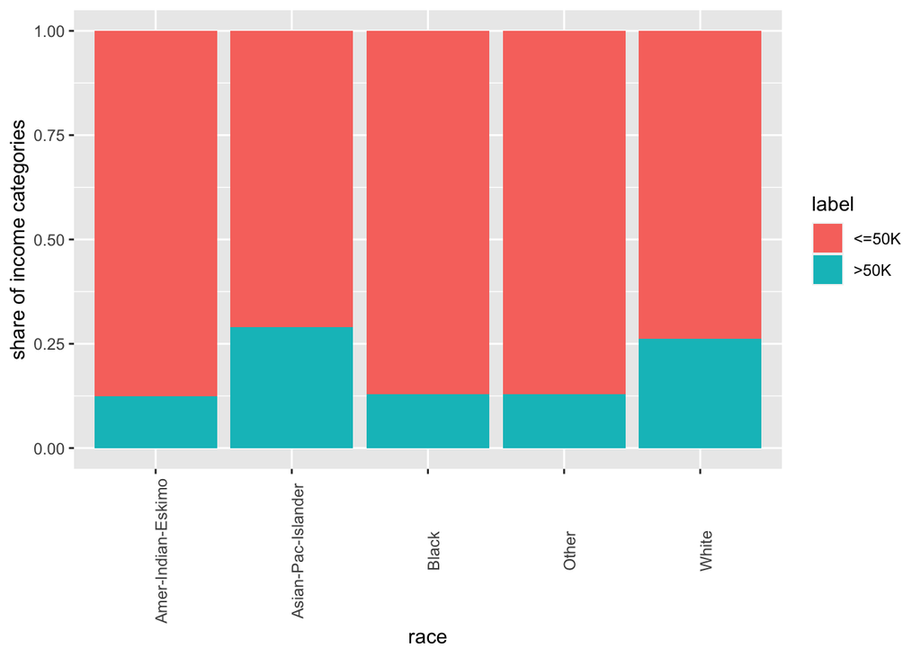

```r
ggplot(data = data_cl) +
    aes(x=race, fill=label, weight = anwgt) +
    geom_bar(position="fill") +
    ylab("share of income categories") +
    theme(axis.text.x = element_text(angle = 90))
```

education x earnings

```r
summary(data_cl$education_num)
```

```
##    Min. 1st Qu.  Median    Mean 3rd Qu.    Max.
##    1.00    9.00   10.00   10.12   13.00   16.00
```

```r
data_cl$edu_fact <- cut(data_cl$education_num, breaks = c(0,4,9,13,16),
                                                labels = c("less than 8", "some high school", "high school diploma", "at least BS"))
wtd_dt<-svydesign(id=~1, weights=~anwgt, data=data_cl)
round(svytable(~edu_fact + label, wtd_dt),0)
```

```
##                      label
## edu_fact              <=50K  >50K
##   less than 8          1665    80
##   some high school    16342  2600
##   high school diploma 14689  6107
##   at least BS          1367  2339
```

```r
round(prop.table(svytable(~edu_fact + label, wtd_dt), margin = 1),2)
```

```
##                      label
## edu_fact              <=50K >50K
##   less than 8          0.95 0.05
##   some high school     0.86 0.14
##   high school diploma  0.71 0.29
##   at least BS          0.37 0.63
```

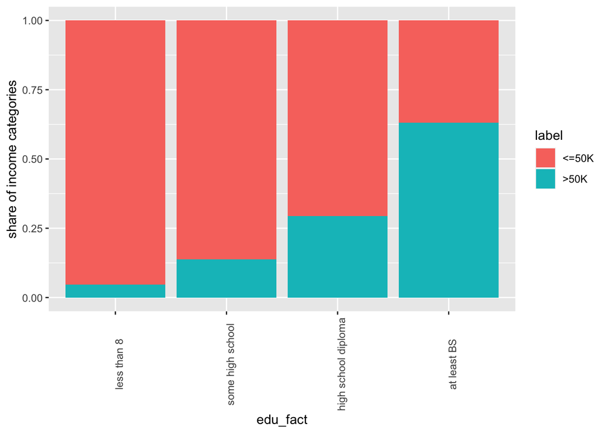

```r
ggplot(data = data_cl) +
    aes(x=edu_fact, fill=label, weight = anwgt) +
    geom_bar(position="fill") +
    ylab("share of income categories") +
    theme(axis.text.x = element_text(angle = 90))
```

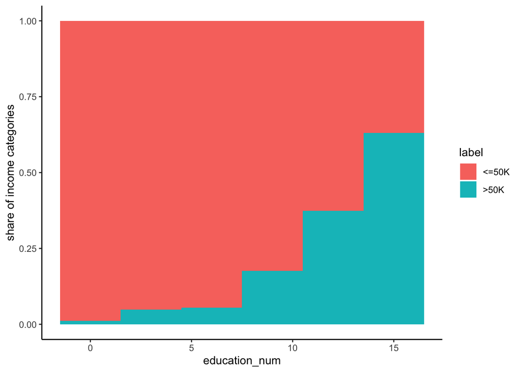

```r
ggplot(data = data_cl) +
    aes(x=education_num, fill=label, weight = anwgt) +
    geom_histogram(binwidth =3, position='fill') +
    ylab("share of income categories") +
    theme_classic()
```

Regarding education, we see the expected results: the more education an individual has, the mroe likely they are to make more than USD 50K a year.

working hrs x earnings

```r
summary(data_cl$hours_per_week)
```

```
##    Min. 1st Qu.  Median    Mean 3rd Qu.    Max.
##    1.00   40.00   40.00   40.94   45.00   99.00
```

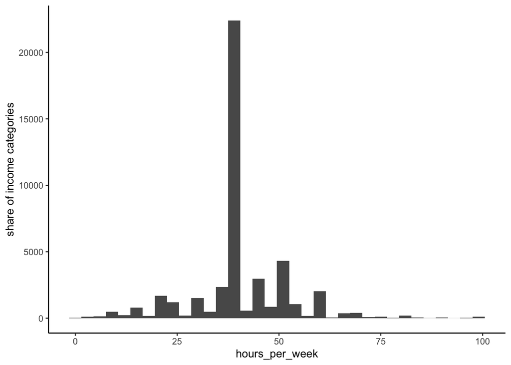

```r
ggplot(data = data_cl) +
    aes(x=hours_per_week, weight = anwgt) +
    geom_histogram(binwidth =3) +
    ylab("share of income categories") +
    theme_classic()
```

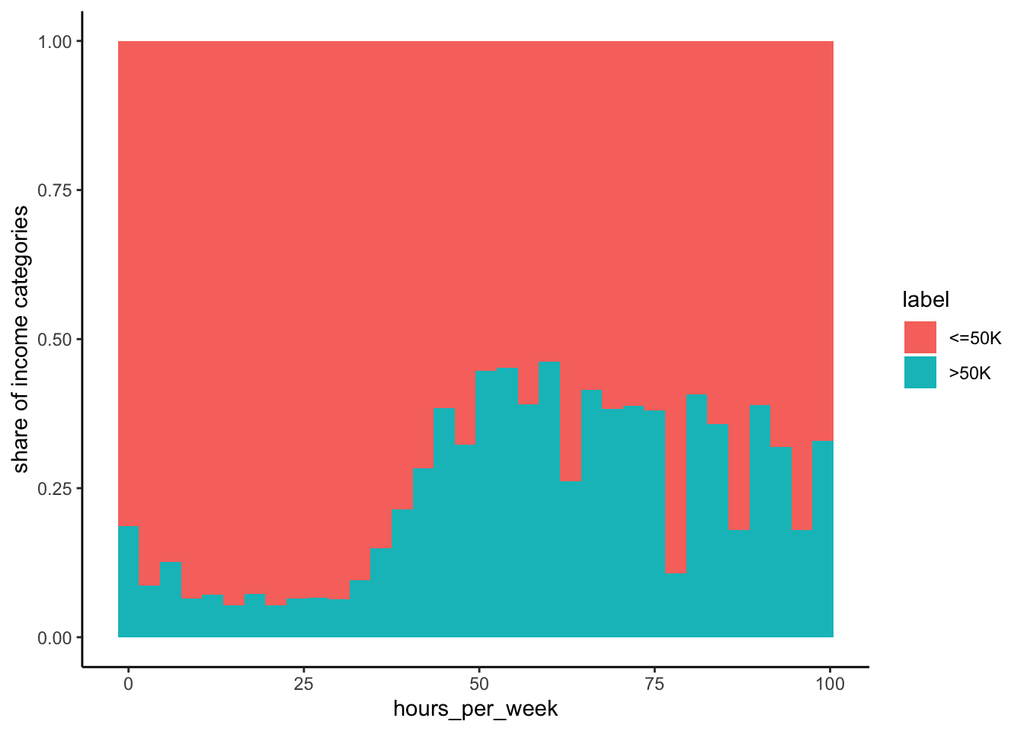

```r
ggplot(data = data_cl) +
    aes(x=hours_per_week, fill=label, weight = anwgt) +
    geom_histogram(binwidth = 3, position='fill') +
    ylab("share of income categories") +
    theme_classic()
```

Weekly hours worked is another variable where a direct relationship is expected between the variable and the probability of making more than USD 50K per annum. We see that working more hours only helps up to a certain level, and those that work the longest hours do not have the highest probability of making more than USD 50K.

country of origin x earnings

```r
#summary(data_cl$native_country)
data_cl$US_born <- ifelse(data_cl$native_country=='United-States', 'US born', 'Other')
data_cl$US_born <- factor(data_cl$US_born, levels = c("US born", "Other"))
wtd_dt<-svydesign(id=~1, weights=~anwgt, data=data_cl)
round(svytable(~US_born + label, wtd_dt),0)
```

```
##          label
## US_born   <=50K  >50K
##   US born 30390 10339
##   Other    3672   787
```

```r
round(prop.table(svytable(~US_born + label, wtd_dt), margin = 1),2)
```

```
##          label
## US_born   <=50K >50K
##   US born  0.75 0.25
##   Other    0.82 0.18
```

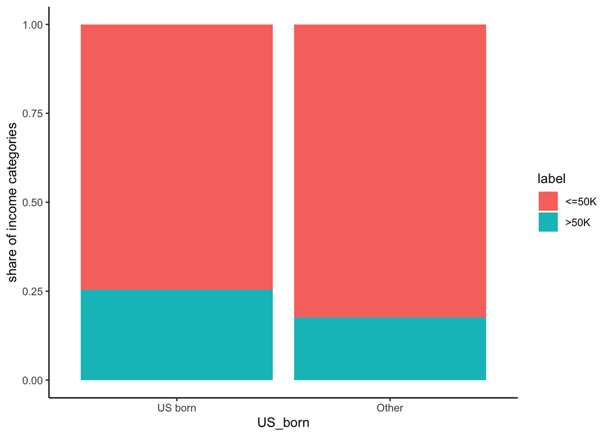

```r
ggplot(data = data_cl) +
    aes(x=US_born, fill=label, weight = anwgt) +
    geom_bar(position="fill") +
    ylab("share of income categories") +
    theme_classic()
```

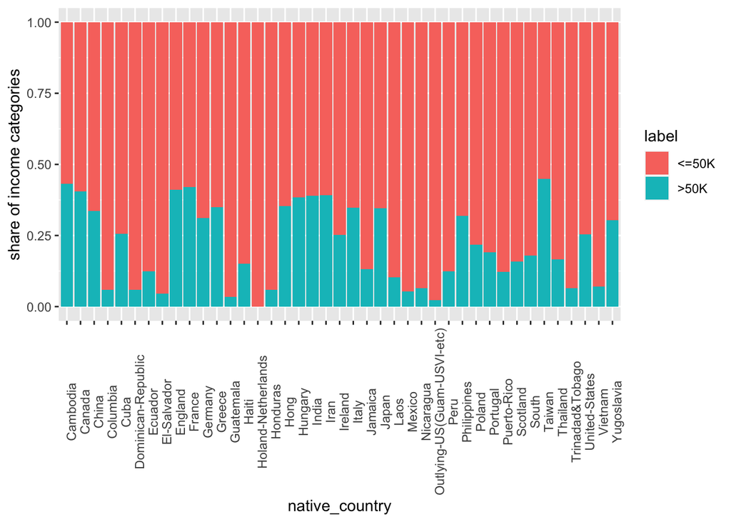

```r
ggplot(data = data_cl) +
    aes(x=native_country, fill=label, weight = anwgt) +
    geom_bar(position="fill") +
    ylab("share of income categories") +
    theme(axis.text.x = element_text(angle = 90))
```

In general, people born in the US have a higher probability of making above USD 50K per year. However, being foreign born is not necessarily deterministic. People coming from more developed countries tend to have higher probabilities of belonging to the >50K group even compared to US born people.

workclass x earnings

```r
wtd_dt<-svydesign(id=~1, weights=~anwgt, data=data_cl)
round(svytable(~workclass + label, wtd_dt),0)
```

```
##                   label
## workclass          <=50K  >50K
##   Federal-gov        820   542
##   Local-gov         2169   938
##   Private          26545  7233
##   Self-emp-inc       664   887
##   Self-emp-not-inc  2490  1014
##   State-gov         1358   510
##   Without-pay         17     2
```

```r
round(prop.table(svytable(~workclass + label, wtd_dt), margin = 1),2)
```

```
##                   label
## workclass          <=50K >50K
##   Federal-gov       0.60 0.40
##   Local-gov         0.70 0.30
##   Private           0.79 0.21
##   Self-emp-inc      0.43 0.57
##   Self-emp-not-inc  0.71 0.29
##   State-gov         0.73 0.27
##   Without-pay       0.91 0.09
```

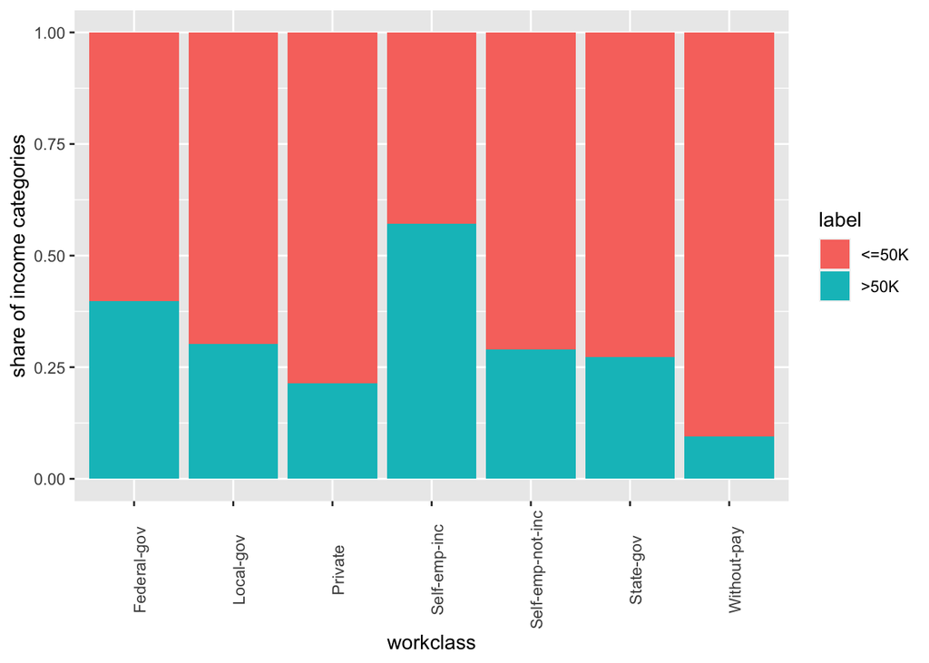

```r
ggplot(data = data_cl) +
    aes(x=workclass,fill=label, weight = anwgt) +
    geom_bar(position="fill") +
    ylab("share of income categories") +
    theme(axis.text.x = element_text(angle = 90))
```

The vast majority works in the private sector. Other sectors seem to be providing better opportunities: individuals working for any governmental organizations or working as self-employed tend to have a higher probability of making more than USD 50K.

occupation x earnings

```r
wtd_dt<-svydesign(id=~1, weights=~anwgt, data=data_cl)
round(svytable(~occupation + label, wtd_dt),0)
```

```
##                    label
## occupation          <=50K >50K
##   Adm-clerical       4847  752
##   Armed-Forces         11    6
##   Craft-repair       4733 1365
##   Exec-managerial    3049 2820
##   Farming-fishing    1211  126
##   Handlers-cleaners  2035  139
##   Machine-op-inspct  2667  357
##   Other-service      4567  192
##   Priv-house-serv     233    2
##   Prof-specialty     3181 2677
##   Protective-serv     710  328
##   Sales              3962 1466
##   Tech-support       1004  416
##   Transport-moving   1854  482
```

```r
round(prop.table(svytable(~occupation + label, wtd_dt), margin = 1),2)
```

```
##                    label
## occupation          <=50K >50K
##   Adm-clerical       0.87 0.13
##   Armed-Forces       0.66 0.34
##   Craft-repair       0.78 0.22
##   Exec-managerial    0.52 0.48
##   Farming-fishing    0.91 0.09
##   Handlers-cleaners  0.94 0.06
##   Machine-op-inspct  0.88 0.12
##   Other-service      0.96 0.04
##   Priv-house-serv    0.99 0.01
##   Prof-specialty     0.54 0.46
##   Protective-serv    0.68 0.32
##   Sales              0.73 0.27
##   Tech-support       0.71 0.29
##   Transport-moving   0.79 0.21
```

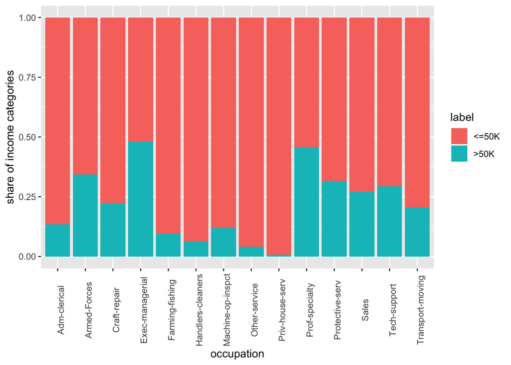

```r
ggplot(data = data_cl) +
    aes(x= occupation,fill=label, weight = anwgt) +
    geom_bar(position="fill") +
    ylab("share of income categories") +
    theme(axis.text.x = element_text(angle = 90))
```

Occupation also shows the expected impact on the probability of belonging to the >50K group.

marital_status x earnings

```r
round(svytable(~marital_status + label, wtd_dt),0)
```

```
##                        label
## marital_status          <=50K  >50K
##   Divorced               5489   636
##   Married-AF-spouse        18    12
##   Married-civ-spouse    11223  9495
##   Married-spouse-absent   529    48
##   Never-married         14319   716
##   Separated              1404   112
##   Widowed                1080   107
```

```r
round(prop.table(svytable(~marital_status + label, wtd_dt), margin = 1),2)
```

```
##                        label
## marital_status          <=50K >50K
##   Divorced               0.90 0.10
##   Married-AF-spouse      0.59 0.41
##   Married-civ-spouse     0.54 0.46
##   Married-spouse-absent  0.92 0.08
##   Never-married          0.95 0.05
##   Separated              0.93 0.07
##   Widowed                0.91 0.09
```

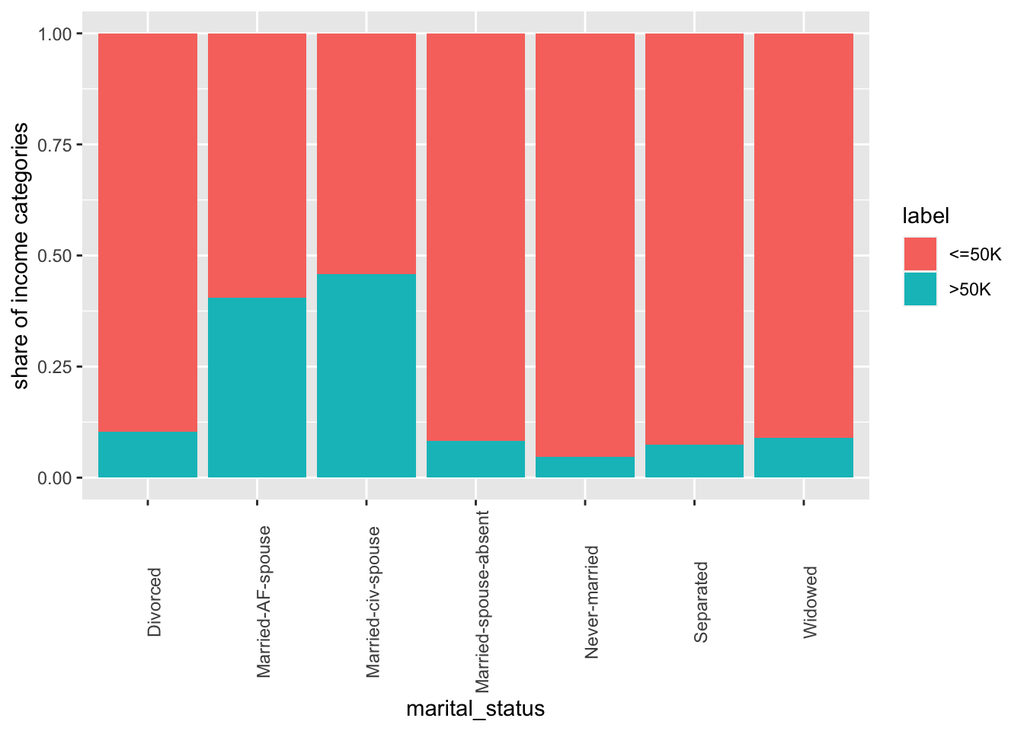

```r
ggplot(data = data_cl) +
    aes(x=marital_status, fill=label, weight = anwgt) +
    geom_bar(position="fill") +
    ylab("share of income categories") +
    theme(axis.text.x = element_text(angle = 90))
```

relationship x earnings

```r
round(svytable(~relationship + label, wtd_dt),0)
```

```
##                 label
## relationship     <=50K  >50K
##   Husband         9944  8459
##   Not-in-family  10510  1233
##   Other-relative  1406    46
##   Own-child       6662   104
##   Unmarried       4533   297
##   Wife            1006   987
```

```r
round(prop.table(svytable(~relationship + label, wtd_dt), margin = 1),2)
```

```
##                 label
## relationship     <=50K >50K
##   Husband         0.54 0.46
##   Not-in-family   0.89 0.11
##   Other-relative  0.97 0.03
##   Own-child       0.98 0.02
##   Unmarried       0.94 0.06
##   Wife            0.50 0.50
```

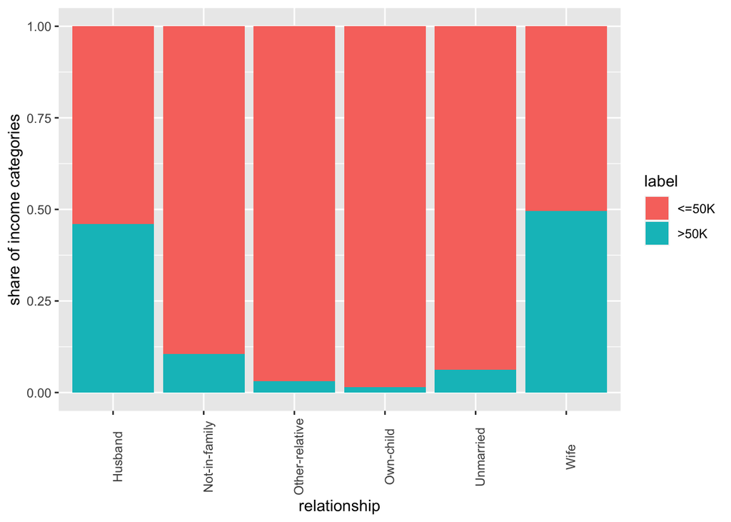

```r
ggplot(data = data_cl) +
    aes(x=relationship, fill=label, weight = anwgt) +
    geom_bar(position="fill") +
    ylab("share of income categories") +
    theme(axis.text.x = element_text(angle = 90))
```

Finally, we can see that both the marital status and the relationship (family role) variables are related to making more than USD 50K a year. However, in the case of these variables age is likely to be a confounding variable.

#### Multivariate plots

In the next section, I visually explore how controlling for some of the variables affects the relationship between gender and the probability of belonging to the >50K group. First, let’s have a look at the relationship of gender, age and high income, and then I investigate the relationship between gender, education and high income.

gender x age x earnings

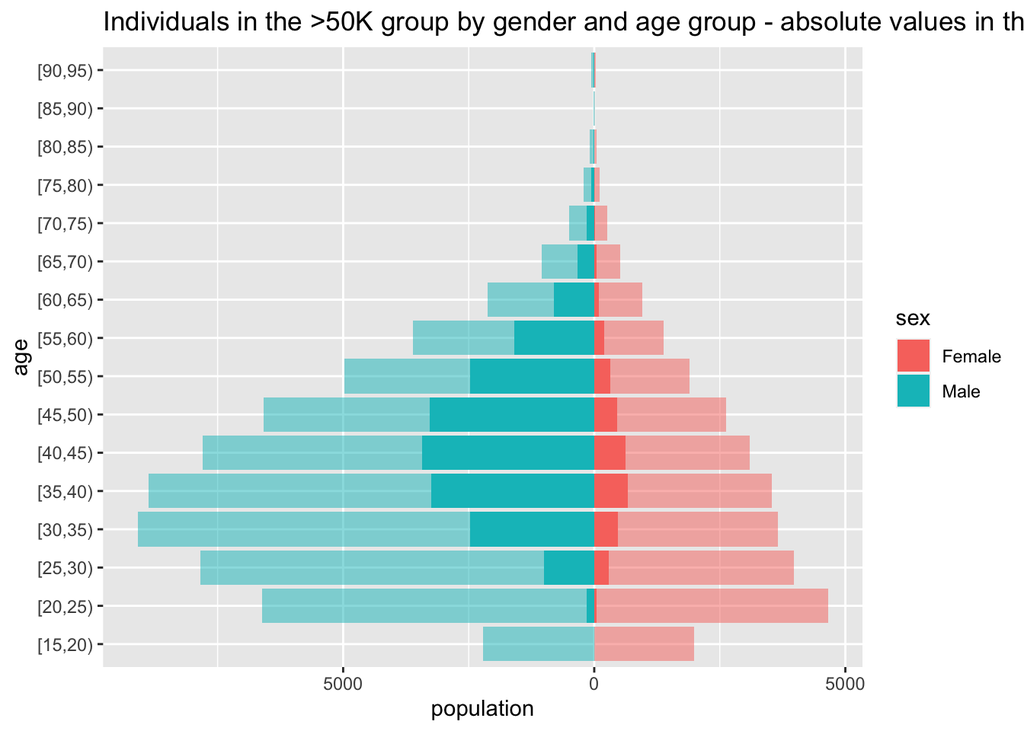

```r
data_cl$income_high <- ifelse(data_cl$label=='>50K', 1, 0)
# cut age into age groups
data_cl$age_gr <- cut(data_cl$age, breaks = seq(0, 100, 5), right = FALSE)
# gender x education x income
age_data <- aggregate(formula = anwgt ~ sex + age_gr , data = data_cl, FUN = sum)
age_data_h <- aggregate(formula = anwgt ~ sex + age_gr , data = data_cl[data_cl$income_high == 1,], FUN = sum)
age_data_h$population <- ifelse(age_data_h$sex == "Male", -1*age_data_h$anwgt, age_data_h$anwgt)
age_data$population <- ifelse(age_data$sex ==  "Male", -1*age_data$anwgt, age_data$anwgt)

# pyramid chart to display absolute values
ggplot(age_data, aes(x = age_gr, y = population, fill = sex)) +
    geom_bar(data = subset(age_data, sex == "Female"), stat = "identity", alpha = .5) +
    geom_bar(data = subset(age_data, sex == "Male"), stat = "identity", alpha = .5) +
    geom_bar(data = subset(age_data_h, sex == "Male"), stat = "identity") +
    geom_bar(data = subset(age_data_h, sex == "Female"), stat = "identity") +
    scale_y_continuous(labels = paste0(as.character(c(10000,5000,0,5000)))) +
    xlab("age") +
    ggtitle("Individuals in the >50K group by gender and age group - absolute values in the sample") +
    coord_flip()
```

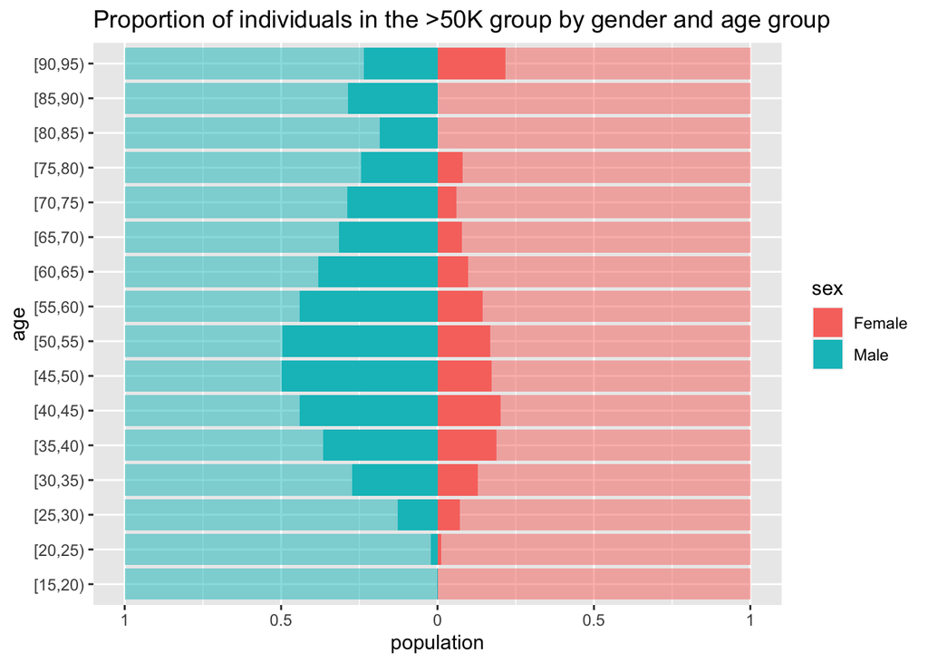

```r
# displaying proportions
age_data_tot <- merge(age_data, age_data_h[,c('age_gr','sex','population')], by=c('age_gr','sex'), all.x = T)
age_data_tot[is.na(age_data_tot$population.y),]$population.y <- 0
age_data_tot$high_prop <- age_data_tot$population.y/age_data_tot$population.x
age_data_rich <- age_data_tot[,c('age_gr', 'sex', 'high_prop')]
colnames(age_data_rich)[3] <- 'population'
age_data_rich$population <- ifelse(age_data_rich$sex == "Male", -1*age_data_rich$population, age_data_rich$population)
age_data_tot$population <- ifelse(age_data_tot$sex == "Male", -1, 1)

# pyramid chart to display proportions
ggplot(age_data_tot, aes(x = age_gr, y = population, fill = sex)) +
    geom_bar(data = subset(age_data_tot, sex == "Female"), stat = "identity", alpha = .5) +
    geom_bar(data = subset(age_data_tot, sex == "Male"), stat = "identity", alpha = .5) +
    geom_bar(data = subset(age_data_rich, sex == "Male"), stat = "identity") +
    geom_bar(data = subset(age_data_rich, sex == "Female"), stat = "identity") +
    scale_y_continuous(labels = paste0(as.character(c(1,0.5,0,0.5,1)))) +
    ggtitle("Proportion of individuals in the >50K group by gender and age group") +
    xlab("age")+
    coord_flip()
```

The pyramid charts displaying the relationship between gender, age and earnigns above <50K suggests that even after controlling for age, the relationship between gender and high income is traceable: except for the oldest people in the sample, out of a woman and man of the same age, the woman is less likely to make more than USD 50K a year.

gender x education x income

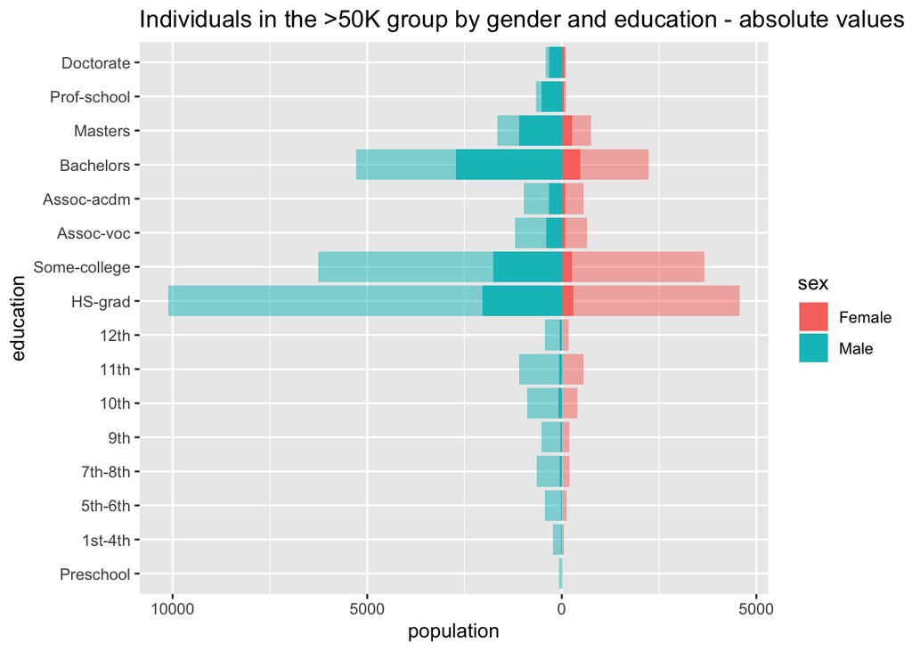

```r
edu_data <- aggregate(formula = anwgt ~ sex + education + education_num, data = data_cl, FUN = sum)
edu_data_h <- aggregate(formula = anwgt ~ sex + education + education_num, data = data_cl[data_cl$income_high == 1,], FUN = sum)
edu_data_h$population <- ifelse(edu_data_h$sex == "Male", -1*edu_data_h$anwgt, edu_data_h$anwgt)
edu_data$population <- ifelse(edu_data$sex ==  "Male", -1*edu_data$anwgt, edu_data$anwgt)

# pyramid chart to display absolute values
ggplot(edu_data, aes(x = reorder(education, education_num), y = population, fill = sex)) +
    geom_bar(data = subset(edu_data, sex == "Female"), stat = "identity", alpha = .5) +
    geom_bar(data = subset(edu_data, sex == "Male"), stat = "identity", alpha = .5) +
    geom_bar(data = subset(edu_data_h, sex == "Male"), stat = "identity") +
    geom_bar(data = subset(edu_data_h, sex == "Female"), stat = "identity") +
    scale_y_continuous(labels = paste0(as.character(c(10000,5000,0,5000)))) +
    xlab("education") +
    ggtitle("Individuals in the >50K group by gender and education - absolute values in the sample") +
    coord_flip()
```

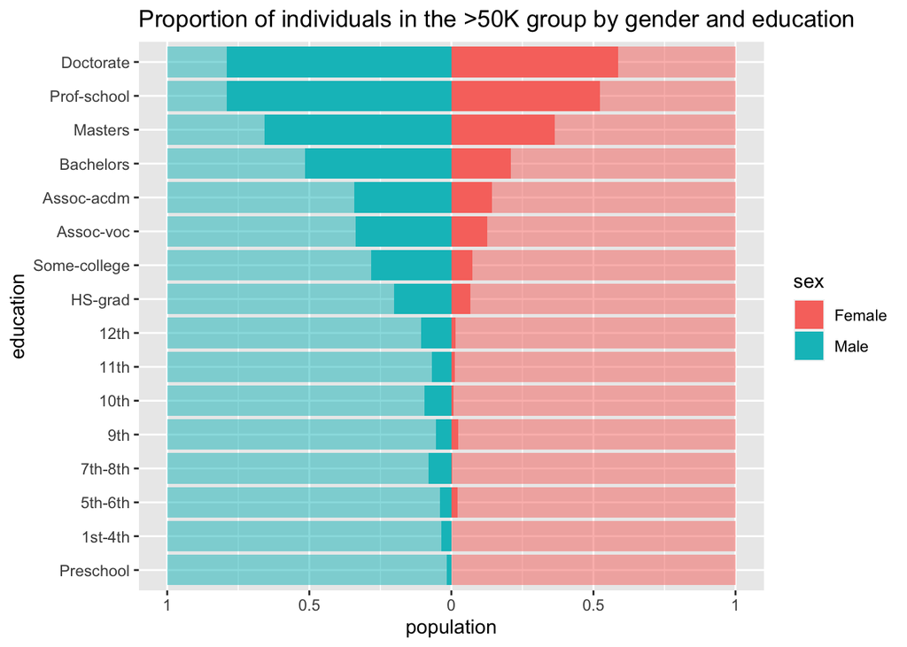

```r
# displaying proportions
edu_data_tot <- merge(edu_data, edu_data_h[,c('education','sex','population')], by=c('education','sex'), all.x = T)
edu_data_tot[is.na(edu_data_tot$population.y),]$population.y <- 0
edu_data_tot$high_prop <- edu_data_tot$population.y/edu_data_tot$population.x
edu_data_rich <- edu_data_tot[,c('education', 'education_num', 'sex', 'high_prop')]
colnames(edu_data_rich)[4] <- 'population'
edu_data_rich$population <- ifelse(edu_data_rich$sex == "Male", -1*edu_data_rich$population, edu_data_rich$population)
edu_data_tot$population <- ifelse(edu_data_tot$sex == "Male", -1, 1)

# pyramid chart to display proportions
ggplot(edu_data_tot, aes(x = reorder(education, education_num), y = population, fill = sex)) +
    geom_bar(data = subset(edu_data_tot, sex == "Female"), stat = "identity", alpha = .5) +
    geom_bar(data = subset(edu_data_tot, sex == "Male"), stat = "identity", alpha = .5) +
    geom_bar(data = subset(edu_data_rich, sex == "Male"), stat = "identity") +
    geom_bar(data = subset(edu_data_rich, sex == "Female"), stat = "identity") +
    scale_y_continuous(labels = paste0(as.character(c(1,0.5,0,0.5,1)))) +
    ggtitle("Proportion of individuals in the >50K group by gender and education") +
    xlab("education")+
    coord_flip()
```

Once again, the relationship between gender and belonging to the >50K group is not overwritten by the inclusion of education. It is true about all level of education that if a man and a woman have the same level of education, the man will be more likely to make more than USD 50K annually.

## Extracting insights - multivariate explorations

So far, we’ve seen that the relationship between gender and the probability of making above USD 50K remains visible even when controlling for some third variables. In the last part of my exploratory analysis, I will make an effort to quantify this relationship, and determine how much more likely are men to belong to the >50K group compared to women. I use logistic regression to investigate this relationship. First, I have a look at some basic models, and I eventually include most available control variables.

1. Basic univariate model (odds ratio could be also read from contingency table)

```r
model1 <- glm(income_high ~ sex, data = data_cl, family = binomial, weights = anwgt)
stargazer(model1, type = 'text')
```

```
##
## =============================================
##                       Dependent variable:
##                   ---------------------------
##                           income_high
## ---------------------------------------------
## sexMale                    1.253***
##                             (0.029)
##
## Constant                   -2.061***
##                             (0.026)
##
## ---------------------------------------------
## Observations                45,171
## Log Likelihood            -24,715.000
## Akaike Inf. Crit.         49,434.010
## =============================================
## Note:             *p<0.1; **p<0.05; ***p<0.01
```

```r
exp(cbind(OR = coef(model1), confint(model1)))
```

```
##                    OR     2.5 %    97.5 %
## (Intercept) 0.1273357 0.1208813 0.1340423
## sexMale     3.5001552 3.3069806 3.7066620
```

Our first univariate model suggests that for men the odds of making more than 50K a year is 3.5 times as much as for women. As expected with the large sample size, this value is statistically significant, with a 95% confidence interval of 3.3 and 3.7.

2. Model including other basic demographic variables

```r
data_cl$race <- relevel(data_cl$race, "White")
data_cl$age_gr2 <- cut(data_cl$age, breaks = c(0,50,75,100), labels = c("under 50", "50-75", "75+"))
model2 <- glm(income_high ~ sex + age_gr2 + race + education_num + US_born, data = data_cl, family = binomial, weights = anwgt)
stargazer(model2, type = 'text')
```

```
##
## ==================================================
##                            Dependent variable:
##                        ---------------------------
##                                income_high
## --------------------------------------------------
## sexMale                         1.333***
##                                  (0.031)
##
## age_gr250-75                    0.673***
##                                  (0.031)
##
## age_gr275+                       -0.271
##                                  (0.198)
##
## raceAmer-Indian-Eskimo          -0.592***
##                                  (0.191)
##
## raceAsian-Pac-Islander           -0.049
##                                  (0.084)
##
## raceBlack                       -0.527***
##                                  (0.046)
##
## raceOther                       -0.356**
##                                  (0.173)
##
## education_num                   0.379***
##                                  (0.006)
##
## US_bornOther                    -0.294***
##                                  (0.052)
##
## Constant                        -6.184***
##                                  (0.071)
##
## --------------------------------------------------
## Observations                     45,171
## Log Likelihood                 -21,251.170
## Akaike Inf. Crit.              42,522.340
## ==================================================
## Note:                  *p<0.1; **p<0.05; ***p<0.01
```

```r
round(exp(cbind(OR = coef(model2), confint(model2))),4)
```

```
##                            OR  2.5 % 97.5 %
## (Intercept)            0.0021 0.0018 0.0024
## sexMale                3.7917 3.5690 4.0303
## age_gr250-75           1.9600 1.8457 2.0813
## age_gr275+             0.7627 0.5122 1.1132
## raceAmer-Indian-Eskimo 0.5532 0.3746 0.7936
## raceAsian-Pac-Islander 0.9517 0.8067 1.1210
## raceBlack              0.5904 0.5388 0.6461
## raceOther              0.7006 0.4932 0.9747
## education_num          1.4612 1.4454 1.4773
## US_bornOther           0.7456 0.6731 0.8249
```

The second model shows that even after controlling for the main demographic variables, the strong relationship between gender and making more than 50K annually remains. The OR is even slightly larger, nearly 3.8.

3. Model including all control variables

```r
# transform relationship variable to get rid of deterministic relationship between gender and husband/wife
data_cl$relationship <- recode_factor(data_cl$relationship, "Husband"="Spouse", "Wife"="Spouse")
model3 <- glm(income_high ~ sex + age_gr2 + education_num + race + US_born +
                                hours_per_week + marital_status + relationship + workclass + occupation,
                                data = data_cl, family = binomial, weights = anwgt)
stargazer(model3, type = 'text')
```

```
##
## ===============================================================
##                                         Dependent variable:
##                                     ---------------------------
##                                             income_high
## ---------------------------------------------------------------
## sexMale                                      0.168***
##                                               (0.042)
##
## age_gr250-75                                 0.287***
##                                               (0.035)
##
## age_gr275+                                    -0.216
##                                               (0.224)
##
## education_num                                0.300***
##                                               (0.008)
##
## raceAmer-Indian-Eskimo                       -0.545***
##                                               (0.211)
##
## raceAsian-Pac-Islander                         0.012
##                                               (0.099)
##
## raceBlack                                    -0.187***
##                                               (0.054)
##
## raceOther                                     -0.144
##                                               (0.194)
##
## US_bornOther                                 -0.311***
##                                               (0.059)
##
## hours_per_week                               0.027***
##                                               (0.001)
##
## marital_statusMarried-AF-spouse              2.482***
##                                               (0.472)
##
## marital_statusMarried-civ-spouse             2.394***
```

[output cut: 77 more lines]

```
## occupationTech-support                       0.550***
##                                               (0.086)
##
## occupationTransport-moving                    -0.141*
##                                               (0.077)
##
## Constant                                     -6.620***
##                                               (0.241)
##
## ---------------------------------------------------------------
## Observations                                  45,171
## Log Likelihood                              -16,445.090
## Akaike Inf. Crit.                           32,970.180
## ===============================================================
## Note:                               *p<0.1; **p<0.05; ***p<0.01
```

```r
round(exp(cbind(OR = coef(model3), confint(model3))),4)
```

```
##                                          OR  2.5 %  97.5 %
## (Intercept)                          0.0013 0.0008  0.0021
## sexMale                              1.1825 1.0898  1.2831
## age_gr250-75                         1.3327 1.2439  1.4279
## age_gr275+                           0.8057 0.5146  1.2385
## education_num                        1.3503 1.3306  1.3704
## raceAmer-Indian-Eskimo               0.5798 0.3787  0.8661
## raceAsian-Pac-Islander               1.0126 0.8332  1.2294
## raceBlack                            0.8298 0.7465  0.9216
## raceOther                            0.8663 0.5868  1.2550
## US_bornOther                         0.7326 0.6518  0.8224
## hours_per_week                       1.0277 1.0250  1.0304
## marital_statusMarried-AF-spouse     11.9643 4.6609 29.9127
## marital_statusMarried-civ-spouse    10.9553 7.3046 16.3564
## marital_statusMarried-spouse-absent  1.1131 0.7808  1.5569
## marital_statusNever-married          0.5352 0.4715  0.6076
## marital_statusSeparated              1.0582 0.8405  1.3222
## marital_statusWidowed                1.2070 0.9488  1.5238
## relationshipNot-in-family            1.6176 1.0849  2.3999
## relationshipOther-relative           0.4121 0.2821  0.5911
## relationshipOwn-child                0.4245 0.2867  0.6203
## relationshipUnmarried                1.0615 0.6967  1.6099
## workclassLocal-gov                   0.5269 0.4430  0.6266
## workclassPrivate                     0.5708 0.4934  0.6605
## workclassSelf-emp-inc                0.8809 0.7268  1.0680
## workclassSelf-emp-not-inc            0.4103 0.3460  0.4865
## workclassState-gov                   0.4153 0.3424  0.5034
## workclassWithout-pay                 0.2225 0.0278  0.9812
## occupationArmed-Forces               1.1987 0.2774  4.8947
## occupationCraft-repair               0.9977 0.8849  1.1254
## occupationExec-managerial            2.1911 1.9539  2.4587
## occupationFarming-fishing            0.3321 0.2628  0.4171
## occupationHandlers-cleaners          0.4737 0.3822  0.5840
## occupationMachine-op-inspct          0.6630 0.5671  0.7741
## occupationOther-service              0.4101 0.3413  0.4910
## occupationPriv-house-serv            0.1810 0.0273  0.6079
## occupationProf-specialty             1.7983 1.5963  2.0268
## occupationProtective-serv            1.4820 1.2249  1.7921
## occupationSales                      1.3119 1.1599  1.4844
## occupationTech-support               1.7335 1.4657  2.0495
## occupationTransport-moving           0.8683 0.7472  1.0086
```

Finally, the last model including most variables available in the dataset as controls (using three age groups instead of continous age, the numerical version of education, transformed version of relationship, binary version of native country and ignoring the capital gain and loss variables), we can see that the relationship between gender and belonging to the higher income group weakens: eventually, if we compare a man and a woman coming from the same demographic background and working in a similar position, the odds ratio of belonging to the >50K group decreases to 1.2.

To get a sense of the quality of the logistic regression model, I run a Hosmer-Lemeshow goodness of fit test.

```r
hltest(data_cl$income_high, model3$fitted.values)
```

```
##
##  Modified Hosmer-Lemeshow test for large samples
##  H0: epsilon<=epsilon0 vs. Ha: epsilon>epsilon0
##  In-sample goodness of fit.
##
## data:  Model evaluated on 45171 observations
## HL statistic = 27.331, dof = 8.00000, lambda = 0.33911, p-value =
## 0.0009504
## alternative hypothesis: true epsilon is greater than 0.002739948
## 95 percent confidence interval:
##  0.01251551        Inf
## sample estimates:
## epsilonHat
## 0.02068704
```

Unfortunately, the test provides evidence for the poor fit of the model. To find a better model and investigate more how gender and membership in the >50K group are related, it would be beneficial to further transform variables/include extra information not available in the dataset.

## Conclusion

In this data analysis I focused two things:

First, I assessed the quality of the data at hand. As the description of the datafile mentioned, the dataset came reasonably cleaned. Some of the remaining issues to be handled were missing/unknown values, duplicates, outliers, and inconsistencies within the variables. With the variables at hand, some of the problematic values would be rather difficult to impute/correct, while in the case of other values, successful imputation seems more likely. For the puprose of the current analysis, I decided to either not use the problematic variables or simply leave out the observations containing the problematic values. I visually demonstrated how this tranformation does not change the representativeness of the data along the variables (gender, race, age) that were used in the weighting process.